# Relatorio Final - Corrigido 1

# 3. Produtividade

## 3.1. Visualização dos Dados

Nas figuras abaixo, estão representadas o efeito das taxas de aplicação e adjuvantes sobre a produtividade.

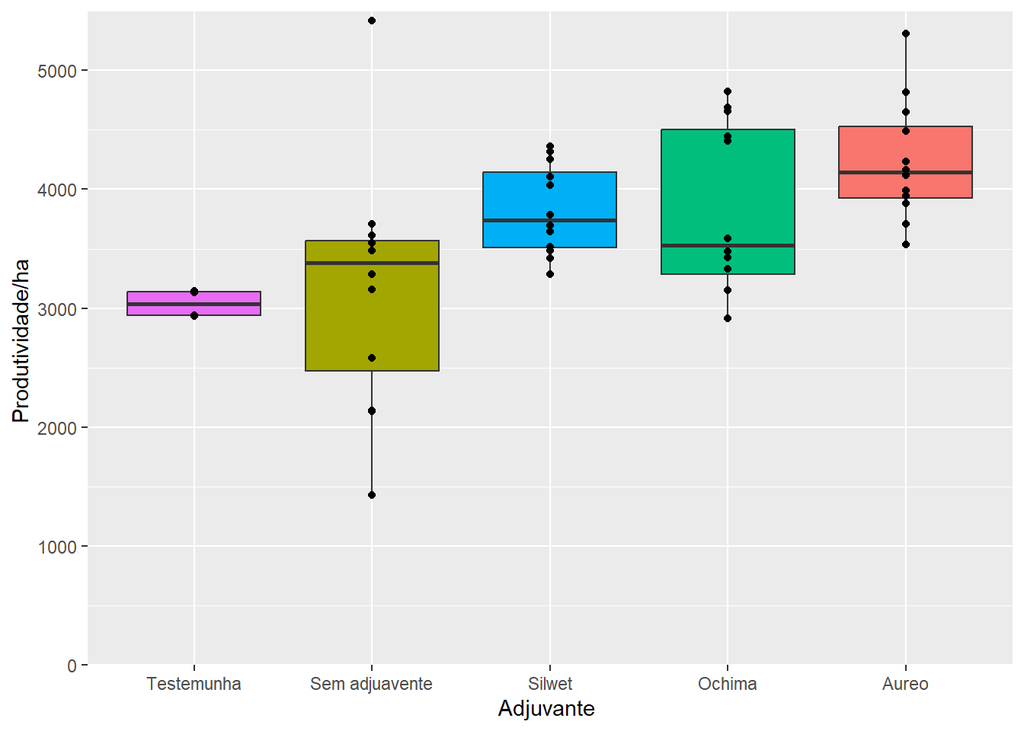

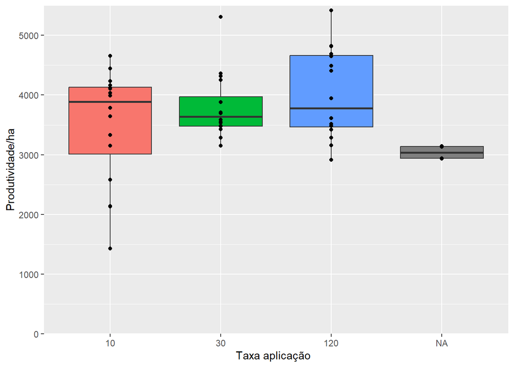

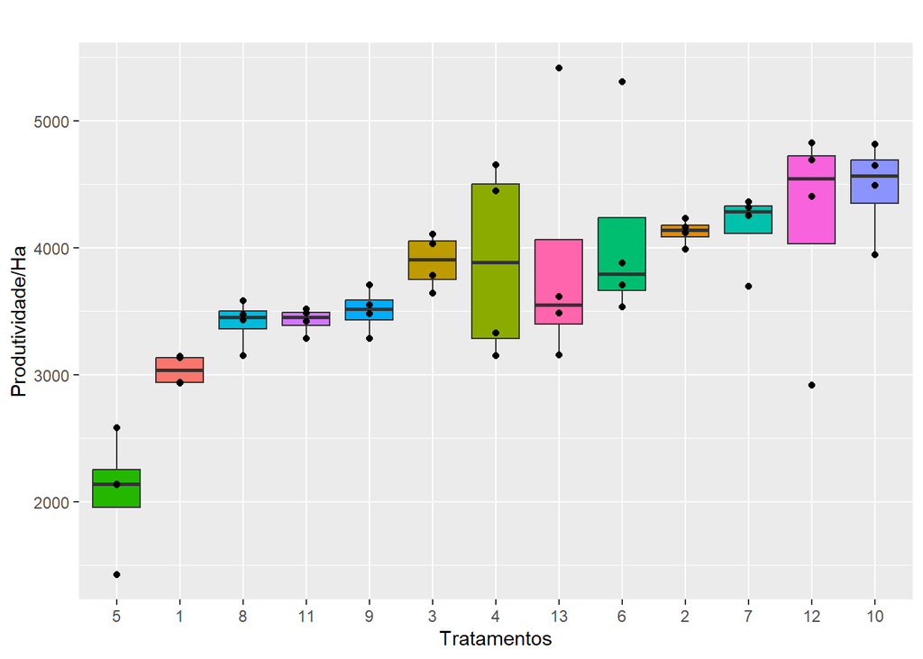

## 3.2. Análise Descritiva

**Produtividade**

| **Adjuvante** | **Taxa** | **Média** | **Desvio** |
| --- | --- | --- | --- |
| Aureo | 10 | 4126.628 | 101.8045 |
| Aureo | 30 | 4107.253 | 813.5231 |
| Aureo | 120 | 4474.647 | 378.0488 |
| Sem adjuvante | 10 | 2072.590 | 477.5598 |
| Sem adjuvante | 30 | 3505.489 | 175.0681 |
| Sem adjuvante | 120 | 3917.943 | 1018.2044 |
| Ochima | 10 | 3896.058 | 764.9150 |
| Ochima | 30 | 3411.327 | 183.7392 |
| Ochima | 120 | 4208.948 | 878.6541 |
| Silwet | 10 | 3891.961 | 214.8625 |
| Silwet | 30 | 4157.376 | 309.3058 |
| Silwet | 120 | 3428.174 | 102.3050 |
| Testemunha | NA | 3037.673 | 117.0120 |

## 3.3. Análise Inferencial

#### I - Sem testemunha

##### Pressupostos da ANOVA

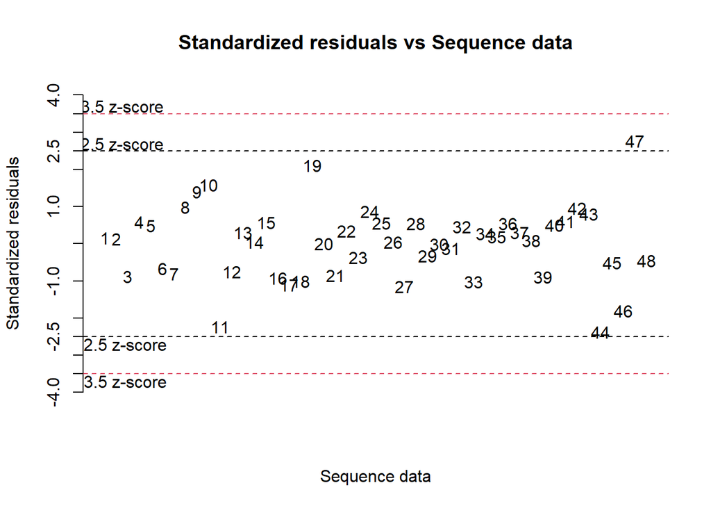

```
                                    values
p.value Shapiro-Wilk test           0.3441
p.value Bartlett test (factor_1)    0.1936
p.value Bartlett test (factor_2)    0.4071
p.value Bartlett test (treatments)  0.1488
coefficient of variation (%)       14.2000
first value most discrepant        47.0000
second value most discrepant       44.0000
third value most discrepant        11.0000
```

- Pelo teste Shapiro-Wilk, os resíduos são normalmente distribuídos (p>0.05).
- Pelo teste de Bartlett, as variâncias dos fatores são iguais (p>0.05).

##### ANOVA

**Anova da produtividade**

| Tratamento | df | type III SS | mean square | F value | p>F |
| --- | --- | --- | --- | --- | --- |
| Adjuvante | 3 | 7088787 | 2362928.9 | 8.257 | <0.001 |
| Taxa | 2 | 2105798 | 1052899.0 | 3.6792 | 0.0361 |
| Blocos | 3 | 1517496 | 505832.0 | 1.7676 | 0.1725 |
| Ajuvante:Taxa | 6 | 8122816 | 1353802.7 | 4.7307 | 0.0014 |
| Resíduos | 33 | 9443747 | 286174.1 | - | - |

**valor de α = 0.05**

Pela análise de variância a 5% de significância:

- Há SIM diferença significativa entre os níveis dos dois fatores (p < 0.05);
- NÃO há diferença significativa entre blocos (p > 0.05);
- Há SIM interação entre os fatores (p < 0.05).

##### Teste post hoc (comparações múltiplas)

**Produtividade**

**Análise Post Hoc ajduvante**

| **Adjuvante** | **Média Ajustada** | **Tukey** |
| --- | --- | --- |
| Aureo | 4236.176 | a |
| Ochima | 3838.777 | a |
| Silwet | 3825.837 | a |
| Sem adjuvante | 3165.341 | b |

**Letras iguais: Níveis não diferem entre si a α = 0.05**

**Produtividade**

**Análise Post Hoc da Taxa de aplicação**

| **Taxa** | **Média ajustada** | **Tukey** |
| --- | --- | --- |
| 120 | 4007.428 | a |
| 30 | 3795.361 | ab |
| 10 | 3496.809 | b |

**Letras iguais: Níveis não diferem entre si a α = 0.05**